# Exam_3_CARS

Raigne

4/15/2020

## Analyzing Data

**Load in Libraries and data:**

**Whats in the mtcars data:**

**A data frame with 32 observations on 11 (numeric) variables.**

**[, 1] mpg Miles/(US) gallon**

**[, 2] cyl Number of cylinders**

**[, 3] disp Displacement (cu.in.)**

**[, 4] hp Gross horsepower**

**[, 5] drat Rear axle ratio**

**[, 6] wt Weight (1000 lbs)**

**[, 7] qsec 1/4 mile time**

**[, 8] vs Engine (0 = V-shaped, 1 = straight)**

**[, 9] am Transmission (0 = automatic, 1 = manual)**

**[,10] gear Number of forward gears**

**[,11] carb Number of carburetors**

**Look for orrelation:**

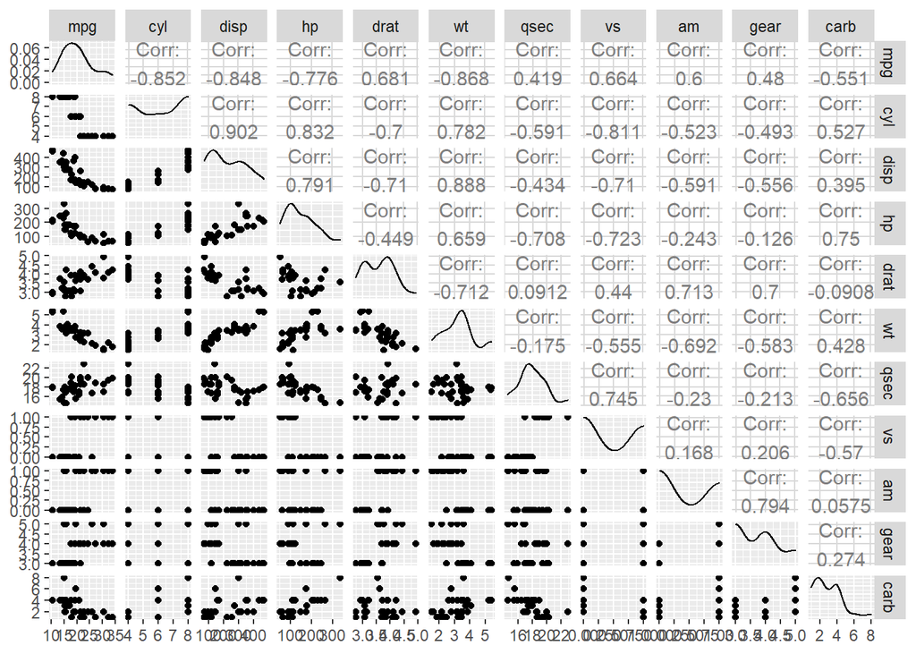

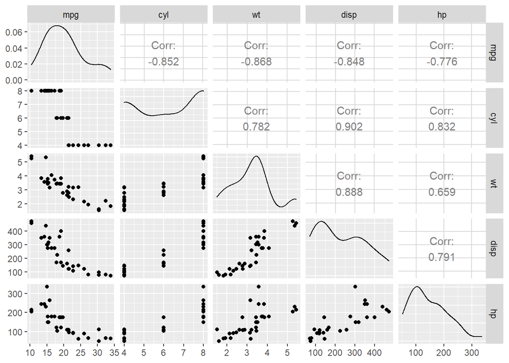

**Comparing all variables to the dependent variable MPG using their correlation values, we see that cyl, wt, disp, drat and hp are the most correlated to mpg. The best model most likely will contain these independent variables. Lets test it!**

**The four chosen models in ascending order:**

```
## mpg ~ hp
```

```
## mpg ~ hp + wt
```

```
## mpg ~ hp * wt
```

```
## mpg ~ hp * cyl * wt + disp + drat
```

**Compare the 4 models**

```
##
## Call:
## lm(formula = mpg ~ hp, data = mtcars)
##
## Residuals:
##     Min      1Q  Median      3Q     Max
## -5.7121 -2.1122 -0.8854  1.5819  8.2360
##
## Coefficients:
##             Estimate Std. Error t value Pr(>|t|)
## (Intercept) 30.09886    1.63392  18.421  < 2e-16 ***
## hp          -0.06823    0.01012  -6.742 1.79e-07 ***
## ---
## Signif. codes:  0 '***' 0.001 '**' 0.01 '*' 0.05 '.' 0.1 ' ' 1
##
## Residual standard error: 3.863 on 30 degrees of freedom
## Multiple R-squared:  0.6024, Adjusted R-squared:  0.5892
## F-statistic: 45.46 on 1 and 30 DF,  p-value: 1.788e-07
```

```
##
## Call:
## lm(formula = mpg ~ hp + wt, data = mtcars)
##
## Residuals:
##    Min     1Q Median     3Q    Max
## -3.941 -1.600 -0.182  1.050  5.854
##
## Coefficients:
##             Estimate Std. Error t value Pr(>|t|)
## (Intercept) 37.22727    1.59879  23.285  < 2e-16 ***
## hp          -0.03177    0.00903  -3.519  0.00145 **
## wt          -3.87783    0.63273  -6.129 1.12e-06 ***
## ---
## Signif. codes:  0 '***' 0.001 '**' 0.01 '*' 0.05 '.' 0.1 ' ' 1
##
## Residual standard error: 2.593 on 29 degrees of freedom
## Multiple R-squared:  0.8268, Adjusted R-squared:  0.8148
## F-statistic: 69.21 on 2 and 29 DF,  p-value: 9.109e-12
```

```
##
## Call:
## lm(formula = mpg ~ hp * wt, data = mtcars)
##
## Residuals:
##     Min      1Q  Median      3Q     Max
## -3.0632 -1.6491 -0.7362  1.4211  4.5513
##
## Coefficients:
##             Estimate Std. Error t value Pr(>|t|)
## (Intercept) 49.80842    3.60516  13.816 5.01e-14 ***
## hp          -0.12010    0.02470  -4.863 4.04e-05 ***
## wt          -8.21662    1.26971  -6.471 5.20e-07 ***
## hp:wt        0.02785    0.00742   3.753 0.000811 ***
## ---
## Signif. codes:  0 '***' 0.001 '**' 0.01 '*' 0.05 '.' 0.1 ' ' 1
##
## Residual standard error: 2.153 on 28 degrees of freedom
## Multiple R-squared:  0.8848, Adjusted R-squared:  0.8724
## F-statistic: 71.66 on 3 and 28 DF,  p-value: 2.981e-13
```

```
##
## Call:
## lm(formula = mpg ~ hp * cyl * wt + disp + drat, data = mtcars)
##
## Residuals:
##     Min      1Q  Median      3Q     Max
## -3.3656 -1.3983 -0.1626  1.3083  3.8673
##
## Coefficients:
##              Estimate Std. Error t value Pr(>|t|)
## (Intercept) 45.280518  35.444272   1.278    0.215
## hp          -0.025020   0.277987  -0.090    0.929
## cyl         -0.547782   6.654882  -0.082    0.935
## wt          -2.100132  11.768419  -0.178    0.860
## disp        -0.004699   0.012497  -0.376    0.710
## drat        -0.255658   1.534742  -0.167    0.869
## hp:cyl      -0.005627   0.042220  -0.133    0.895
## hp:wt       -0.039141   0.109074  -0.359    0.723
## cyl:wt      -0.419730   2.085379  -0.201    0.842
## hp:cyl:wt    0.006870   0.015287   0.449    0.658
##
## Residual standard error: 2.299 on 22 degrees of freedom
## Multiple R-squared:  0.8967, Adjusted R-squared:  0.8544
## F-statistic: 21.22 on 9 and 22 DF,  p-value: 7.276e-09
```

**Check the MSE (mean squared error) of each model and pick the one with least error compared to reality(ascending order 1-4)**

```
## [1] 13.98982
```

```
## [1] 6.095242
```

```
## [1] 4.055047
```

```
## [1] 3.634881
```

**We see that model 4 has the best fit. (3.634)**

**Lets do a cross-validation and test it.**

**If we train our model on the full data set, it can become “over-trained” In other words, we want to make sure our model works for the SYSTEM, not just the data set** **Set seed and divide mtcars randomly in half. Train model on first half and test on second half:**

```r
set.seed(123) # set reproducible random number seed
set <- caret::createDataPartition(mtcars$mpg, p=.5) # pick random subset of data
set <- set$Resample1 # convert to vector

train <- mtcars[set,] # subset mtcars using the random row numbers we made
test <- mtcars[-set,] # The other half of the mtcars
```

**Build cross validation model from model 4** **and test it on other half of data**

```
## mpg ~ hp * cyl * wt + disp + drat
```

**plot actaul mpg against predictions**

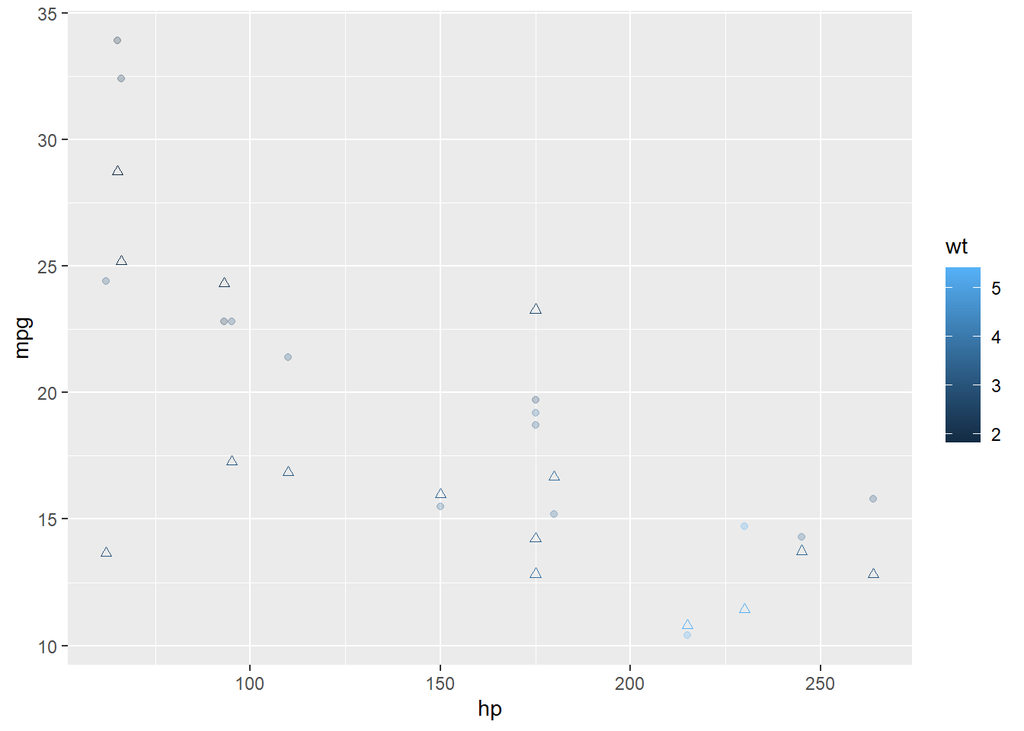

**Now lets compare are over fitted model 4 to VC-model 4, using MSE**

```
## [1] 3.634881
```

*Model 4 (3.63)*

```
## [1] 22.89757
```

*CV-Model 4 (22.89)*

**Plot and compare Model 4 to CV-Model 4**

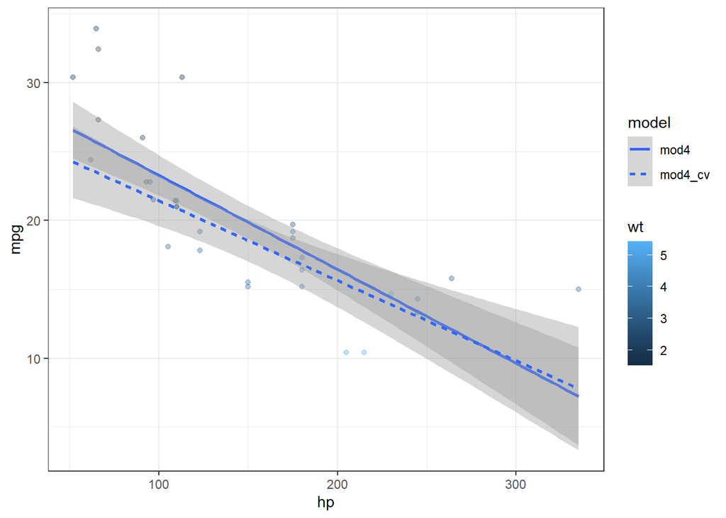

.

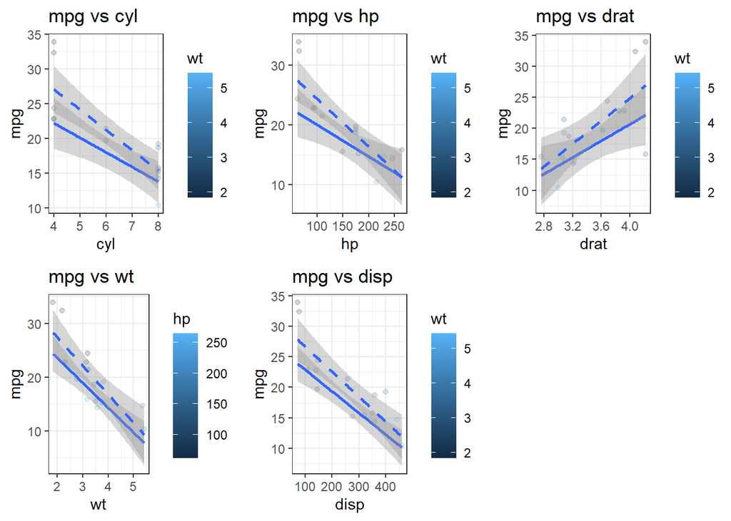

```r
df1 <- gather_predictions(test,mod4_cv)

p1 <- ggplot(df1, aes(x=cyl,color=wt)) +
  geom_point(aes(y=mpg),alpha=.2) +
  geom_smooth(method = "lm",aes(y=pred))+
  geom_smooth(method = "lm",linetype="dashed", aes(y=mpg))+ theme_bw()+
  labs(title = "mpg vs cyl")

p2 <- ggplot(df1, aes(x=hp,color=wt)) +
  geom_point(aes(y=mpg),alpha=.2) +
  geom_smooth(method = "lm",aes(y=pred))+
  geom_smooth(method = "lm",linetype="dashed", aes(y=mpg))+ theme_bw()+
  labs(title = "mpg vs hp")


p3 <- ggplot(df1, aes(x=drat,color=wt)) +
  geom_point(aes(y=mpg),alpha=.2) +
  geom_smooth(method = "lm",aes(y=pred))+
  geom_smooth(method = "lm",linetype="dashed", aes(y=mpg))+ theme_bw()+
  labs(title = "mpg vs drat")

p4 <- ggplot(df1, aes(x=wt,color=hp)) +
  geom_point(aes(y=mpg),alpha=.2) +
  geom_smooth(method = "lm",aes(y=pred))+
  geom_smooth(method = "lm",linetype="dashed", aes(y=mpg))+ theme_bw()+
  labs(title = "mpg vs wt")

p5 <- ggplot(df1, aes(x=disp,color=wt)) +
  geom_point(aes(y=mpg),alpha=.2) +
  geom_smooth(method = "lm",aes(y=pred))+
  geom_smooth(method = "lm",linetype="dashed", aes(y=mpg))+ theme_bw()+
  labs(title = "mpg vs disp")
plot_grid(p1,p2,p3,p4,p5)
```